# 3D Computer Vision (WS25/26) - Project

## General Information

Upload: 29.10.2025

**Intermediate Deadline**: 27.11.2025 (Step 1-2)

**Final Deadline**: 23.01.2026 (Step 1-5)

### Your Group

Submitted by Group 06:

- Zahra Parvinashtiani
- Behnam Pourafkham
- Fatemeh Rezaei

### Submission

Please hand in a single **.zip** file named according to the pattern "**groupXX**" (e.g. group00). The contents of the .zip should be as follows:

- folder with the same name as the **.zip** file
  - **.ipynb** file
  - **.html** export of .ipynb with all the outputs you got
  - **data** folder containing necessary files to run the code

By submitting this exercise, you confirm the following:

- **All people** listed above **contributed** to this solution
- **No other people** were **involved** in this solution
- **No contents** of this solution were **copied from others** (this includes people, large language models, websites, etc.)

### Final Presentation

You will be required to present your solution in a 20 minute presentation, which includes:

- Problem Overview
- Solution Overview (e.g. pseudo code, mathematical formulas, visualizations)
- Describe challenges & optimizations

After the presentation, there will be 10 minutes of questions and answers about your work.

## 3D Scene Reconstruction - Task Overview

Your task in this exercise is to do a dense reconstruction of a scene. This will involve multiple steps that you will encounter and learn about as the semester progresses. You can start implementing individual steps as soon as you learn about them or wait until you have learned more to implement everything together. In the latter case, be mindful that this exercise is designed for an entire semester and the workload is accordingly large.

### Given Data

You will be given the following data:

- **9 color images** of the scene.
  - 8 Bit RGB per pixel.
  - Each image rendered from a different position.
  - The camera used had **lens distortion**.
- **9 Depth images** of the scene.
  - 8 Bit Grayscale per pixel. The result of dividing the Z-depth by **each image's maximum** and then multiplying by 255.
  - Each image has the **same pose** as the corresponding RGB image.
  - The camera used was **free of any distortions**.
- 1 Dictionary containing **camera calibration parameters**.
  - They belong to the camera that was used to render the RGB images.
  - Distortion coefficients are given in the standard [k<sub>1</sub>, k<sub>2</sub>, p<sub>1</sub>, p<sub>2</sub>, k<sub>3</sub>] order.
- 1 Numpy array containing **8 camera transformations**.
  - They specify the **movements** that the **camera went through** to render all images.
  - I.e. idx **0** specifies the transformation from **00.png to 01.png**, idx **1** specifies the transformation from **01.png to 02.png**, ...
  - This applies to both RGB and Depth images, as they have the same poses.
- 1 Numpy array containing **7 features**.
  - The features are specified for each of the 9 images.
  - Each feature is a **2D pixel location in "H, W" order**, meaning the first value is the height/row in the image and the second width/column.
  - If a feature was not visible, it was entered as [-1, -1].
  - The features are **unsorted**, meaning that feature idx 0 for 00.png could be corresponding to e.g. feature idx 4 for 01.png.

### Solution Requirements

- Your code needs to **compile**, **run**, and produce an **output**.
- Your target output should be a **dense point cloud** reconstruction (without holes) of the scene.
  - The output should be in the **.ply format**. We provide a function that can exports a .ply file.
  - You may inspect your .ply outputs in e.g. **Meshlab**.
  - See the 'Dense Point Cloud' sample image to get an idea of what is possible. (Meshlab screenshot with point shading set to None; see example under data/samples)
- Your code should be a **general solution**.
  - This means that it could run correctly for a different dataset (with same input structure).
  - It should **NOT** include anything **hardcoded** specific to this dataset.
- Your code should not be unnecessarily inefficient.
  - Our sample solution runs in less than 2 minutes total (including point cloud export).
  - If your solution runs for more than 10 minutes, you are being wasteful in some part of your program.

## Imports

Please note the following:

- These are all imports necessary to achieve the sample results.
- You may remove and/or add other libraries at your own convinience.
- Using library functions (from the given or other libraries) that bypass **necessary computer vision tasks** will not be recognized as 'solved'.
  - E.g.: If you **need** to undistort an image to **get to the next step** of the solution and use the library function cv2.undistort(), then we will evaluate the **undistortion step** as '**failed**'.
  - E.g.: If you **want** to draw points in an image (to **check your method** or **visualize in-between steps**) and use the library function cv2.circle(), then there is **no problem**.
  - E.g.: If you **need** to perform complex **mathematical** operations and use some numpy function, then there is **no problem**.
  - E.g.: You do not like a **provided utility function** and find/know a library function that gives the **same outputs** from the **same inputs**, then there is **no problem**.

```python
import os
import torch
import cv2 as cv
import numpy as np
import matplotlib.pyplot as plt
import glob
#make plots interactive:
#%matplotlib widget
```

## Data Preparation

```python
#Inputs
base_path = os.getcwd()
data_path = os.path.join(base_path,f"data")
img_path = os.path.join(data_path, 'images')
depth_path = os.path.join(data_path, 'depths')
print(f"The project's root path is '{base_path}'.")
print(f"Reading data from '{data_path}'.")
print(f"Image folder: '{img_path}'.")
print(f"Depth folder: '{depth_path}'.")

#Outputs
out_path = os.path.join(base_path, 'output')
ply_path = os.path.join(out_path, 'point_cloud')
os.makedirs(out_path, exist_ok=True)
os.makedirs(ply_path, exist_ok=True)
print(f"\nCreating directory '{out_path}'.")
print(f"Creating directory '{ply_path}'.")

#Load Data
camera_calibration = np.load(os.path.join(data_path, 'camera_calibration.npy'), allow_pickle=True)
camera_calibration = camera_calibration.item()#get dictionary from numpy array struct
given_features = np.load(os.path.join(data_path, 'given_features.npy'), allow_pickle=True)
camera_movement = np.load(os.path.join(data_path, 'camera_movement.npy'), allow_pickle=True)

print(f"\nCamera Calibration:")
for entry in camera_calibration.items():
    print(f"  {entry[0]}: {entry[1]}")
print(f"Camera Movement: {camera_movement.shape}")#[Cameras-1, 4, 4]
print(f"2D Features (Unsorted): {given_features.shape}")#[Camera_idx, Feature_idx, 2]
```

```
The project's root path is '/Users/behnam/Desktop/project'.
Reading data from '/Users/behnam/Desktop/project/data'.
Image folder: '/Users/behnam/Desktop/project/data/images'.
Depth folder: '/Users/behnam/Desktop/project/data/depths'.

Creating directory '/Users/behnam/Desktop/project/output'.
Creating directory '/Users/behnam/Desktop/project/output/point_cloud'.

Camera Calibration:
  distortion_param: [-0.1, 0.02, 0.0, 0.0, -0.01]
  image_height: 551
  image_width: 881
  principal_point: [275.0, 440.0]
  focal_length_mm: 25
  sensor_width_mm: 35
  pixel_ratio: 1.0
  pixel_per_mm: 25.17142857142857
  focal_length_px: 629.2857142857142
Camera Movement: (8, 4, 4)
2D Features (Unsorted): (9, 7, 2)
```

## Provided Utility Functions

These functions are provided to reduce the complexity of some steps you might encounter. They were involved in the creation of the given samples. However, you do not have to use them and can use other means of achieving the same results.

```python
def sample_image(numpy_image, numpy_sample_grid):
    '''
    This function samples a target image from a source image (numpy_image) based on specified pixel coordinates (numpy_sample_grid).
    Inputs:
        numpy_image: of shape=[H, W, C]. H is the height, W is the width, and C is the color channel of the source image from which color values will be sampled.
        numpy_sample_grid: of shape=[H, W, UV]. H is the height and W is the width of the target image that will be sampled. UV are the pixel locations in the source image from which to sample color values.
    Outputs:
        sampled_image: of shape=[H, W, C]. H is the height, W is the width, and C is the color channel of the target image that was sampled.

    The following is a simple toy example to see the behavior of the sample_image function

    example_source = (np.random.rand(110, 220, 3)*255).astype(int) #[110, 220, 3]
    example_grid = np.ones([100, 200, 2]) #[100, 200, 2]
    example_grid[:, :, 1] = 2
    example_target = sample_image(example_source, example_grid) #[100, 200, 3]

    example_target will be of shape [100, 200, 3]
    -> 100, because example_grid has a height of 100
    -> 200, because example_grid has a width of 200
    -> 3, because example_source has a color channel of 3
    print(example_source.shape)

    example_target will contain the value of example_source[2, 1] at every pixel
    -> 2, because example_grid[:, :, 1] has a value of 2 for every pixel
    -> 1, because example_grid[:, :, 0] has a value of 1 for every pixel
    print(example_source[2, 1, 0], "->", np.unique(example_target[:, :, 0]))
    print(example_source[2, 1, 1], "->", np.unique(example_target[:, :, 1]))
    print(example_source[2, 1, 2], "->", np.unique(example_target[:, :, 2]))

    '''
    height, width, _ = numpy_image.shape#[H, W, 3]

    #turn numpy array to torch tensor
    torch_sample_grid = torch.from_numpy(numpy_sample_grid)#[H, W, 2]
    #normalize from range (0, width-1) to (0, 1)
    torch_sample_grid[:, :, 0] = torch_sample_grid[:, :, 0] / (width-1)
    #normalize from range (0, height-1) to (0, 1)
    torch_sample_grid[:, :, 1] = torch_sample_grid[:, :, 1] / (height-1)
    #normalize from range (0, 1) to (-1, 1)
    torch_sample_grid = torch_sample_grid*2 -1

    #transform to necessary shapes
    torch_sample_grid = torch_sample_grid.unsqueeze(0)#[1, H, W, 2]
    torch_image = torch.from_numpy(numpy_image).double().permute(2, 0, 1).unsqueeze(0)#[1, 3, H, W]
    #sample image according to sample grid locations from source image
    sampled_image = torch.nn.functional.grid_sample(torch_image, torch_sample_grid, mode='bilinear', padding_mode='zeros', align_corners=True)
    #transform back to numpy image
    sampled_image = sampled_image.squeeze().permute(1, 2, 0).numpy().astype(np.uint8)#[H, W, 3]
    return sampled_image

def ply_creator(input_3d, rgb_data=None, filename='dummy'):
    ''' Creates a colored point cloud that you can visualise using e.g. Meshlab.
    Inputs:
        input_3d: of shape=[N, 3], each row is the 3D coordinate of each point
        rgb_data(optional): of shape=[N, 3], each row is the rgb color value of each point
        filename: file name for the .ply file to be created
    '''
    assert (input_3d.ndim==2),"Pass 3d points as NumPointsX3 array "
    pre_text1 = """ply\nformat ascii 1.0"""
    pre_text2 = "element vertex "
    pre_text3 = """property float x\nproperty float y\nproperty float z\nproperty uchar red\nproperty uchar green\nproperty uchar blue\nend_header"""
    pre_text22 = pre_text2 + str(input_3d.shape[0])
    pre_text11 = pre_text1
    pre_text33 = pre_text3
    filename = filename + '.ply'
    fid = open(filename, 'w')
    fid.write(pre_text11)
    fid.write('\n')
    fid.write(pre_text22)
    fid.write('\n')
    fid.write(pre_text33)
    fid.write('\n')
    for i in range(input_3d.shape[0]):
        for c in range(3):
            fid.write(str(input_3d[i,c]) + ' ')
        if not rgb_data is None:
            for c in range(3):
                fid.write(str(rgb_data[i,c]) + ' ')
        if i!=input_3d.shape[0]:
            fid.write('\n')
    fid.close()
    return filename
```

## Step 1: Undistortion of the RGB Images

As described in the Given Data section, the RGB images contain lens distortion, while the depth images are already undistorted. To ensure accurate 3D reconstruction, the two modalities must be aligned.

Undistort all RGB images, then visualize one example image before and after undistortion.

```
Distortion coefficients:  [-0.1, 0.02, 0.0, 0.0, -0.01]
FIXED K:
 [[629.28571429   0.         440.        ]
 [  0.         629.28571429 275.        ]
 [  0.           0.           1.        ]]
Saved undistorted image to /Users/behnam/Desktop/project/output/0.png
Saved undistorted image to /Users/behnam/Desktop/project/output/1.png
Saved undistorted image to /Users/behnam/Desktop/project/output/2.png
Saved undistorted image to /Users/behnam/Desktop/project/output/3.png
Saved undistorted image to /Users/behnam/Desktop/project/output/4.png
Saved undistorted image to /Users/behnam/Desktop/project/output/5.png
Saved undistorted image to /Users/behnam/Desktop/project/output/6.png
Saved undistorted image to /Users/behnam/Desktop/project/output/7.png
Saved undistorted image to /Users/behnam/Desktop/project/output/8.png
```

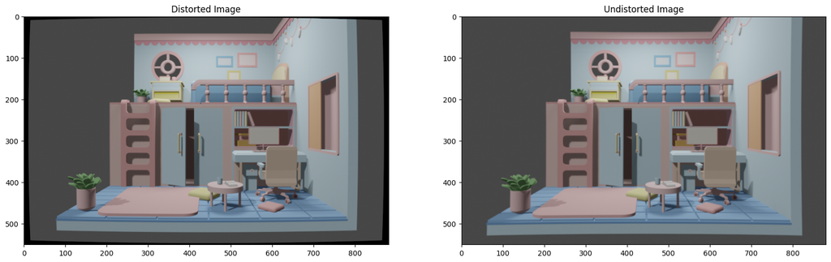

```python
coeffs = camera_calibration['distortion_param']
print("Distortion coefficients: ",coeffs)

focal_length_px = camera_calibration['focal_length_px']
f = float(camera_calibration['focal_length_px'])

# IMPORTANT: your calibration stores principal_point as [cy, cx]
cy, cx = camera_calibration['principal_point']

K = np.array([
    [f, 0, cx],
    [0, f, cy],
    [0, 0, 1]
], dtype=np.float64)

print("FIXED K:\n", K)



def undistort_image_inverse_sampling(image, file_name, K, distortion_params):
    h, w = image.shape[:2]
    k1, k2, p1, p2, k3 = distortion_params[:5]


    u_grid, v_grid = np.meshgrid(np.arange(w), np.arange(h))
    ones = np.ones_like(u_grid)
    pix = np.stack([u_grid, v_grid, ones], axis=-1).reshape(-1, 3).T


    K_inv = np.linalg.inv(K)
    xy1 = K_inv @ pix
    x = xy1[0, :]
    y = xy1[1, :]

    r2 = x * x + y * y
    radial = 1 + k1 * r2 + k2 * (r2 ** 2) + k3 * (r2 ** 3)

    x_dist = x * radial + 2 * p1 * x * y + p2 * (r2 + 2 * x * x)
    y_dist = y * radial + p1 * (r2 + 2 * y * y) + 2 * p2 * x * y

    ones_vec = np.ones_like(x_dist)
    xy1_dist = np.stack([x_dist, y_dist, ones_vec], axis=0)
    pix_dist = K @ xy1_dist

    u_dist = pix_dist[0, :] / pix_dist[2, :]
    v_dist = pix_dist[1, :] / pix_dist[2, :]


    map_x = u_dist.reshape(h, w).astype(np.float32)
    map_y = v_dist.reshape(h, w).astype(np.float32)

    undistorted = cv.remap(image, map_x, map_y, interpolation=cv.INTER_LINEAR, borderMode=cv.BORDER_CONSTANT)

    os.makedirs(out_path, exist_ok=True)
    output_path = os.path.join(out_path, file_name)
    cv.imwrite(output_path, undistorted)
    print(f"Saved undistorted image to {output_path}")
    return undistorted

rgb_paths = sorted(glob.glob(os.path.join(img_path, "*.png")))

for i in range(len(rgb_paths)):
    distorted_image = cv.imread(rgb_paths[i])
    undistorted_image = undistort_image_inverse_sampling(distorted_image, f"{i}.png", K, coeffs)

undistorted_images = sorted(glob.glob(os.path.join(out_path, "*.png")))

plt.figure(figsize=(20, 10))
plt.subplot(1, 2, 1)
plt.imshow(cv.cvtColor(cv.imread(rgb_paths[4]), cv.COLOR_BGR2RGB))
plt.title("Distorted Image")
plt.subplot(1, 2, 2)
plt.imshow(cv.cvtColor(cv.imread(undistorted_images[4]), cv.COLOR_BGR2RGB))
plt.title("Undistorted Image")
plt.show()
```

Example visualization

[figure not shown]

## Step 2: Common Camera Reference Frame

The provided camera poses are expressed relative to consecutive frames (e.g. the first pose is a transformation from the first view to the second view). However, the final point cloud needs to be definied with respect to a single, common world coordinate system.

Compute camera poses such that they are expressed in terms of a shared world reference frame, and then visualize all camera positions and orientations in a single 3D plot.

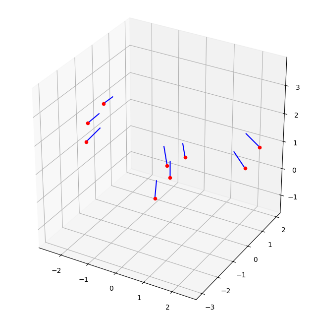

```python
T_c0_to_world = np.eye(4)
camera_to_world = [T_c0_to_world.copy()]

for rel_move in camera_movement:
    T_next = camera_to_world[-1] @ np.linalg.inv(rel_move)

    camera_to_world.append(T_next)


camera_to_world = np.array(camera_to_world)

fig = plt.figure(figsize=(10, 8))
ax = fig.add_subplot(111, projection='3d')

for pose in camera_to_world:
    center = pose[:3, 3]
    rot = pose[:3, :3]
    forward = rot @ np.array([0, 0, 1])
    end = center + 0.6 * forward

    ax.scatter(center[0], center[1], center[2], c='r')
    ax.plot(
        [center[0], end[0]],
        [center[1], end[1]],
        [center[2], end[2]],
        color='b'
    )

centers = camera_to_world[:, :3, 3]
mid = centers.mean(axis=0)
max_r = np.ptp(centers, axis=0).max() / 2.0

ax.set_xlim(mid[0] - max_r, mid[0] + max_r)
ax.set_ylim(mid[1] - max_r, mid[1] + max_r)
ax.set_zlim(mid[2] - max_r, mid[2] + max_r)
ax.set_box_aspect([1, 1, 1])

plt.show()
```

Example visualization

[figure not shown]

## Step 3: Feature Matching and Depth Map Scaling

Each depth map is scaled differently according to its own maximum value. To obtain a consistent dense point cloud, we must correct these scalings so that 3D points from different views align properly.

Perform feature matching across the images, and use the corresponding matches to determine the correct scale factors for the depth maps. Additionally, visualize one selected feature across all views.

```
tracks: 7
scales: [1.         0.8757036  0.7188426  1.0334127  0.9943969  0.6823228
 0.9252722  0.2531778  0.42938632]
```

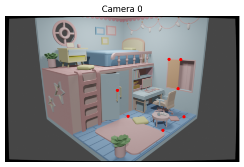

```
Saved: features_all_cams/00.png
```

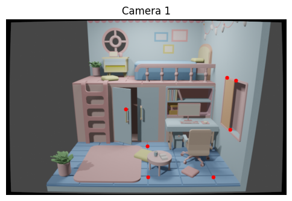

```
Saved: features_all_cams/01.png
```

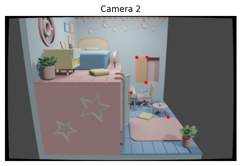

```
Saved: features_all_cams/02.png
```

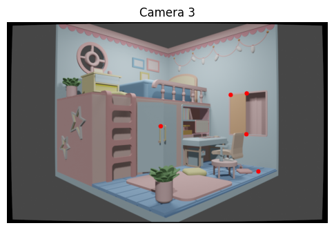

```
Saved: features_all_cams/03.png
```

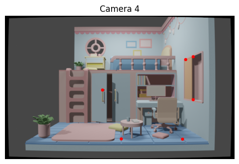

```
Saved: features_all_cams/04.png
```

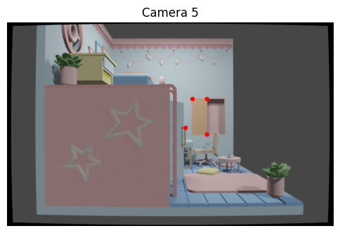

```
Saved: features_all_cams/05.png
```

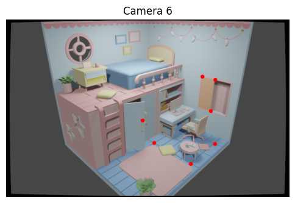

```
Saved: features_all_cams/06.png
```

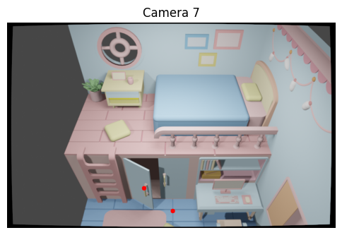

```
Saved: features_all_cams/07.png
```

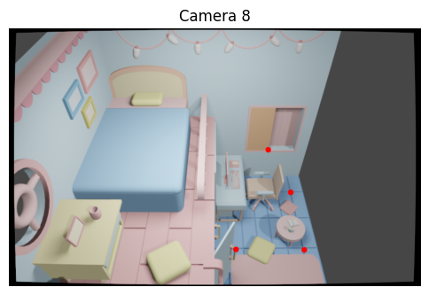

```
Saved: features_all_cams/08.png
```

```python
depth_paths = sorted(glob.glob(os.path.join(depth_path, "*.png")))
depth_imgs = [cv.imread(p, cv.IMREAD_UNCHANGED) for p in depth_paths]
num_cameras = len(depth_imgs)


patch_r = 7

def get_patch(gray, v, u, r=7):
    v0, v1 = max(0, v-r), min(gray.shape[0], v+r+1)
    u0, u1 = max(0, u-r), min(gray.shape[1], u+r+1)
    return gray[v0:v1, u0:u1]

def desc(patch):
    x = patch.astype(np.float32).flatten()
    n = np.linalg.norm(x)
    return x / (n + 1e-8)

def dists(d1, d2):
    return np.linalg.norm(d1 - d2)

def depth_m(depth_img, v, u):
    d = depth_img[int(v), int(u)]
    if depth_img.dtype == np.uint16:
        return d / 1000.0
    return float(d)

#extraction
num_feats = given_features.shape[1]
feature_desc = {}
feature_pos  = {}

for cam_i, img_path in enumerate(undistorted_images):
    img = cv.imread(img_path)
    gray = cv.cvtColor(img, cv.COLOR_BGR2GRAY)

    for feat_i in range(num_feats):
        v, u = given_features[cam_i, feat_i]
        if v < 0 or u < 0:
            continue

        v, u = int(v), int(u)
        patch = get_patch(gray, v, u, patch_r)
        feature_desc[(cam_i, feat_i)] = desc(patch)
        feature_pos[(cam_i, feat_i)]  = (v, u)


threshold = 0.5

tracks = []
track_id = {}


for feat0 in range(num_feats):
    if (0, feat0) in feature_desc:
        tid = len(tracks)
        tracks.append({0: feat0})
        track_id[(0, feat0)] = tid

for cam_i in range(1, num_cameras):

    #go
    best0_for_i = {}
    for feat_i in range(num_feats):
        if (cam_i, feat_i) not in feature_desc:
            continue
        d_i = feature_desc[(cam_i, feat_i)]
        best_feat0, best_dist = None, 1e9
        for feat0 in range(num_feats):
            if (0, feat0) not in feature_desc:
                continue
            dd = dists(d_i, feature_desc[(0, feat0)])
            if dd < best_dist:
                best_dist = dd
                best_feat0 = feat0
        best0_for_i[feat_i] = (best_feat0, best_dist)

    #back
    besti_for_0 = {}
    for feat0 in range(num_feats):
        if (0, feat0) not in feature_desc:
            continue
        d0 = feature_desc[(0, feat0)]
        best_feat_i, best_dist = None, 1e9
        for feat_i in range(num_feats):
            if (cam_i, feat_i) not in feature_desc:
                continue
            dd = dists(d0, feature_desc[(cam_i, feat_i)])
            if dd < best_dist:
                best_dist = dd
                best_feat_i = feat_i
        besti_for_0[feat0] = (best_feat_i, best_dist)

    #threshold
    for feat_i, (feat0, dfwd) in best0_for_i.items():
        if dfwd < threshold:
            back_i, dbwd = besti_for_0[feat0]
            if back_i == feat_i and dbwd < threshold:
                tid = track_id[(0, feat0)]
                tracks[tid][cam_i] = feat_i

feature_groups = [list(t.items()) for t in tracks if len(t) >= 2]
print("tracks:", len(feature_groups))

#scale estimation
fx, fy = K[0,0], K[1,1]
cx, cy = K[0,2], K[1,2]
T = np.array(camera_to_world)

A_rows, b_rows = [], []

for group in feature_groups:
    cams = dict(group)

    feat0 = cams[0]
    v0, u0 = feature_pos[(0, feat0)]
    z0 = depth_m(depth_imgs[0], v0, u0)

    ray0 = np.array([(u0-cx)/fx, (v0-cy)/fy, 1.0], np.float32)
    R0, t0 = T[0,:3,:3], T[0,:3,3]
    a0 = z0 * (R0 @ ray0)

    for cam_i, feat_i in group:
        if cam_i == 0:
            continue

        v, u = feature_pos[(cam_i, feat_i)]
        zi = depth_m(depth_imgs[cam_i], v, u)

        ray = np.array([(u-cx)/fx, (v-cy)/fy, 1.0], np.float32)
        Ri, ti = T[cam_i,:3,:3], T[cam_i,:3,3]
        a1 = zi * (Ri @ ray)

        rhs = ti - t0

        for k in range(3):
            row = np.zeros(num_cameras, np.float32)
            row[0] = a0[k]
            row[cam_i] = -a1[k]
            A_rows.append(row)
            b_rows.append(rhs[k])

A = np.asarray(A_rows, np.float32)
b = np.asarray(b_rows, np.float32)

A0 = A[:,0]
Arest = A[:,1:]
brest = b - A0

x, _, _, _ = np.linalg.lstsq(Arest, brest, rcond=None)

scales = np.zeros(num_cameras, np.float32)
scales[0] = 1.0
scales[1:] = x

print("scales:", scales)

#visualization
output_dir = "features_all_cams"
os.makedirs(output_dir, exist_ok=True)

for cam_i in range(num_cameras):
    img = cv.imread(rgb_paths[cam_i])

    for feat_i in range(given_features.shape[1]):
        v, u = given_features[cam_i, feat_i]
        if v >= 0 and u >= 0:
            cv.circle(img, (int(u), int(v)), 6, (0, 0, 255), -1)

    plt.figure(figsize=(6, 6))
    plt.imshow(cv.cvtColor(img, cv.COLOR_BGR2RGB))
    plt.title("Camera " + str(cam_i))
    plt.axis("off")
    plt.show()

    save_path = os.path.join(output_dir, f"{cam_i:02d}.png")
    cv.imwrite(save_path, img)
    print("Saved:", save_path)
```

Example visualization of the 7 features

[figure not shown]

## Step 4: Depth Map to 3D Points

Using the rescaled depth maps together with the camera poses from Step 2, compute the 3D coordinates for all pixel in each RGB image.

```
A.shape: (255, 9) B.shape: (255,)
Scale :
[1.         3.63812136 4.11496292 3.83155034 3.4480846  3.99121589
 3.8137082  2.47957787 3.30583223]
Number of 3D points: 7
```

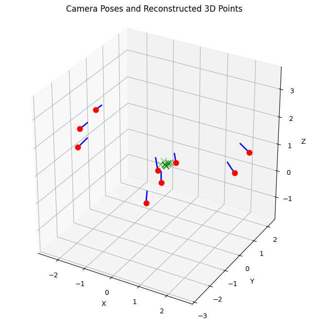

```python
f_x = K[0, 0]
f_y = K[1, 1]
p_x = K[0, 2]
p_y = K[1, 2]

rotations = [pose[:3, :3] for pose in camera_to_world]
translations = [pose[:3, 3] for pose in camera_to_world]

rows_A = []
rows_b = []

for grp in feature_groups:
    if len(grp) < 2:
        continue

    for i in range(len(grp)):
        for j in range(i + 1, len(grp)):

            c1, f1 = grp[i]
            c2, f2 = grp[j]

            v1, u1 = given_features[c1, f1]
            v2, u2 = given_features[c2, f2]

            if any(coord < 0 for coord in [v1, u1, v2, u2]):
                continue

            z1 = depth_imgs[c1][int(v1), int(u1)] / 255.0
            z2 = depth_imgs[c2][int(v2), int(u2)] / 255.0

            if z1 <= 0 or z2 <= 0:
                continue

            r1 = np.array([(u1 - p_x) / f_x, (v1 - p_y) / f_y, 1.0])
            r2 = np.array([(u2 - p_x) / f_x, (v2 - p_y) / f_y, 1.0])

            dir1 = z1 * (rotations[c1] @ r1)
            dir2 = z2 * (rotations[c2] @ r2)

            diff_t = translations[c2] - translations[c1]

            for axis in range(3):
                coeff_vec = np.zeros(num_cameras)
                coeff_vec[c1] = dir1[axis]
                coeff_vec[c2] = -dir2[axis]

                rows_A.append(coeff_vec)
                rows_b.append(diff_t[axis])

A = np.array(rows_A)
b = np.array(rows_b)

print("A.shape:", A.shape, "B.shape:", b.shape)


b_new = b - A[:, 0]
A_new = A[:, 1:]

solution, _, _, _ = np.linalg.lstsq(A_new, b_new, rcond=None)

scales = np.zeros(num_cameras)
scales[0] = 1.0
scales[1:] = solution

print("Scale :")
print(scales)


ref_cam = 0
points_3d = []

for feat_i in range(given_features.shape[1]):

    v, u = given_features[ref_cam, feat_i]
    if v < 0 or u < 0:
        continue

    depth = depth_imgs[ref_cam][int(v), int(u)] / 255.0
    if depth <= 0:
        continue

    depth *= scales[ref_cam]

    ray = np.array([
        (u - cx) / fx,
        (v - cy) / fy,
        1.0
    ])

    T = camera_to_world[ref_cam]
    R, t = T[:3, :3], T[:3, 3]

    P_world = R @ (depth * ray) + t
    points_3d.append(P_world)

points_3d = np.array(points_3d)
print("Number of 3D points:", len(points_3d))

fig = plt.figure(figsize=(10, 8))
ax = fig.add_subplot(111, projection="3d")

for pose in camera_to_world:
    center = pose[:3, 3]
    R = pose[:3, :3]

    forward = R @ np.array([0, 0, 1])
    end = center + 0.4 * forward

    ax.scatter(center[0], center[1], center[2],
               c="red", s=60)

    ax.plot([center[0], end[0]],
            [center[1], end[1]],
            [center[2], end[2]],
            color="blue", linewidth=2)

ax.scatter(points_3d[:, 0],
           points_3d[:, 1],
           points_3d[:, 2],
           c="green", marker="x", s=80)

all_pts = np.vstack([points_3d,
                      np.array([p[:3, 3] for p in camera_to_world])])

mid = all_pts.mean(axis=0)
radius = np.ptp(all_pts, axis=0).max() / 2

ax.set_xlim(mid[0] - radius, mid[0] + radius)
ax.set_ylim(mid[1] - radius, mid[1] + radius)
ax.set_zlim(mid[2] - radius, mid[2] + radius)

ax.set_box_aspect([1, 1, 1])

ax.set_xlabel("X")
ax.set_ylabel("Y")
ax.set_zlabel("Z")

plt.title("Camera Poses and Reconstructed 3D Points")
plt.show()
```

Example visualization of cameras and 3D points (of the 7 features) from one image

[figure not shown]

## Step 5: 3D Points to Point Cloud

Finally, use the provided `ply_creator` function to generate a merged colored point cloud from the computed 3D points from all images. Visualize the resulting point cloud in a viewer such as MeshLab.

```python
import numpy as np
import cv2 as cv
import os
import glob

rgb_paths_used = sorted(glob.glob(os.path.join(out_path, "*.png")))[:num_cameras]

fx, fy, cx, cy = K[0, 0], K[1, 1], K[0, 2], K[1, 2]

step = 4
depth_thresh_u8 = 100

H, W = depth_imgs[0].shape
v_grid, u_grid = np.mgrid[0:H:step, 0:W:step]
u_flat = u_grid.flatten()
v_flat = v_grid.flatten()

points_all = []
colors_all = []

for cam_i in range(num_cameras):
    img = cv.imread(rgb_paths_used[cam_i])
    img = cv.cvtColor(img, cv.COLOR_BGR2RGB)

    depth_map = depth_imgs[cam_i].astype(np.float32) * (scales[cam_i] / 255.0)
    d = depth_map[v_grid, u_grid].flatten()

    valid = d > (depth_thresh_u8 / 255.0) * scales[cam_i]
    if not np.any(valid):
        continue

    z = d[valid]
    x = (u_flat[valid] - cx) * z / fx
    y = (v_flat[valid] - cy) * z / fy
    Pc = np.stack([x, y, z], axis=-1)

    T = camera_to_world[cam_i]
    Pw = (Pc @ T[:3, :3].T) + T[:3, 3]

    rgb = img[v_grid, u_grid].reshape(-1, 3)[valid]

    points_all.append(Pw)
    colors_all.append(rgb)

points_3d = np.concatenate(points_all, axis=0).astype(np.float32)
colors_3d = np.concatenate(colors_all, axis=0).astype(np.uint8)

ply_file = ply_creator(points_3d, colors_3d, os.path.join(ply_path, "Final_Output"))
print(f"Saved: {ply_file}")
print(f"Total points: {points_3d.shape[0]}")
```

```
Saved: /Users/behnam/Desktop/project/output/point_cloud/Final_Output.ply
Total points: 273112
```

Example visualization

[figure not shown]